# Exploratory Data Analysis

11/12/2018

## Introduction

## Definition (Wikipedia)

In statistics, *exploratory data analysis (EDA)* is an approach to analyzing data sets to summarize their main characteristics, often with visual methods. A statistical model can be used or not, but primarily EDA is for seeing what the data can tell us beyond the formal modeling or hypothesis testing task. s.

## The Cervical Cancer dataset

The UCI machine learning public dataset “Cervical cancer (Risk Factors) Data Set”:

“… collected at ‘Hospital Universitario de Caracas’ in Caracas, Venezuela. The dataset comprises demographic information, habits, and historic medical records of 858 patients. Several patients decided not to answer some of the questions because of privacy concerns.”

## Getting to know the data

## Look at the codebook

A codebook describes the contents, structure, and layout of a dataset. A well-documented codebook contains information intended to be complete and self-explanatory for each variable in a data file.

## The cervical cancer Codebook

Is this a good codebook?

```
(int) Age
(int) Number of sexual partners
(int) First sexual intercourse (age)
(int) Num of pregnancies
(int) Hormonal Contraceptives (years)
(int) IUD (years)
(bool) STDs
(int) STDs (number)
...
(bool) Hinselmann: target variable
(bool) Schiller: target variable
(bool) Cytology: target variable
(bool) Biopsy: target variable
```

## Elements of a good codebook entry

- **Name** the column name (num.sex.partner)
- **Full name** what it abbreviates (“Number of sexual partners”)
- **Data type** integer/float/Date/enum/… (int)
- **Unit** the unit of measurement (e.g. “mg/l plasma”")
- **Description** A full description of what is measured, and the way its value was collected. (e.g. questionnaire)

## What if it is not present/complete?

There are several ways to try and find out:  
- read the publication  
- contact the primary investigators  
- *last resort* deduce from context and domain knowledge

## Load the data

- Load the data and check the data type of the columns.
- Beware of unusual encodings for missing data.
- Use `head()` and `str()` to iteratively get data loading right.

```r
datafile <- "data/risk_factors_cervical_cancer.csv"
data <- read.table(datafile, sep=",", header = TRUE)
str(data[1:5])
```

```
## 'data.frame':    858 obs. of  5 variables:
##  $ Age                      : int  18 15 34 52 46 42 51 26 45 44 ...
##  $ Number.of.sexual.partners: Factor w/ 13 levels "?","1.0","10.0",..: 8 2 2 9 7 7 7 2 2 7 ...
##  $ First.sexual.intercourse : Factor w/ 22 levels "?","10.0","11.0",..: 7 6 1 8 13 15 9 18 12 7 ...
##  $ Num.of.pregnancies       : Factor w/ 12 levels "?","0.0","1.0",..: 3 3 3 8 8 6 10 7 9 1 ...
##  $ Smokes                   : Factor w/ 3 levels "?","0.0","1.0": 2 2 2 3 2 2 3 2 2 3 ...
```

```r
data <- read.table(datafile,
                   sep=",",
                   header = TRUE,
                   na.strings = "?")
str(data[1:5])
```

```
## 'data.frame':    858 obs. of  5 variables:
##  $ Age                      : int  18 15 34 52 46 42 51 26 45 44 ...
##  $ Number.of.sexual.partners: num  4 1 1 5 3 3 3 1 1 3 ...
##  $ First.sexual.intercourse : num  15 14 NA 16 21 23 17 26 20 15 ...
##  $ Num.of.pregnancies       : num  1 1 1 4 4 2 6 3 5 NA ...
##  $ Smokes                   : num  0 0 0 1 0 0 1 0 0 1 ...
```

## A better solution

- Create a file called Codebook to store names, descriptions and types of variables

```
##   abbreviation   class                      full.name
## 1          age     int                            Age
## 2 num.partners     int      Number of sexual partners
## 3    first.sex     int First sexual intercourse (age)
## 4     num.preg     int             Num of pregnancies
## 5       smoker logical                         Smokes
## 6  smoke.years     int                Smokes (years)
```

## Correcting typos?

What do you think about this? (From the Attribute Information on the website )

```
(bool) Smokes (years)
(bool) Smokes (packs/year)
```

They are advertised as a boolean, but are they?

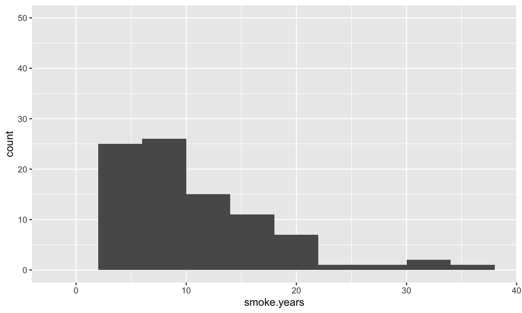

**NB** 722 non-smokers omitted!  
**Obviously, smoke.years should be an int (same for smokes.packs.year)**

## Getting it right in the end

```r
data <- read.csv(datafile, na.strings = "?")
names(data) <- codebook[,1]
for(i in 1:nrow(codebook)) {
  if(codebook[i, 2] == "logical"){
    data[,i] <- as.logical(data[,i])
  }
}
str(data[1:7])
```

```
## 'data.frame':    858 obs. of  7 variables:
##  $ age              : int  18 15 34 52 46 42 51 26 45 44 ...
##  $ num.partners     : num  4 1 1 5 3 3 3 1 1 3 ...
##  $ first.sex        : num  15 14 NA 16 21 23 17 26 20 15 ...
##  $ num.preg         : num  1 1 1 4 4 2 6 3 5 NA ...
##  $ smoker           : logi  FALSE FALSE FALSE TRUE FALSE FALSE ...
##  $ smoke.years      : num  0 0 0 37 0 ...
##  $ smokes.packs.year: num  0 0 0 37 0 0 3.4 0 0 2.8 ...
```

## Why such a hassle?

- It makes it much easier to code from here on
  - and to read the code
- It makes adding labels to plots a breeze
- It allows for easier checking

## Exploring variables

## First steps

- At first, simply use the `summary()` function. This gives you a very quick overview of the data
  - gives first hint of data distribution
  - indicates if anything funny is going on
- Take special care to notice
  - outliers
  - skewed data
  - large amounts of missing data

## Inspecting some columns (1)

```
##   num.partners      first.sex
##  Min.   : 1.000   Min.   :10
##  1st Qu.: 2.000   1st Qu.:15
##  Median : 2.000   Median :17
##  Mean   : 2.528   Mean   :17
##  3rd Qu.: 3.000   3rd Qu.:18
##  Max.   :28.000   Max.   :32
##  NA's   :26       NA's   :7
```

- Are these summaries you would expect?
- Do you see (hints of) outliers?

## Boxplot is a visual representation of the summary

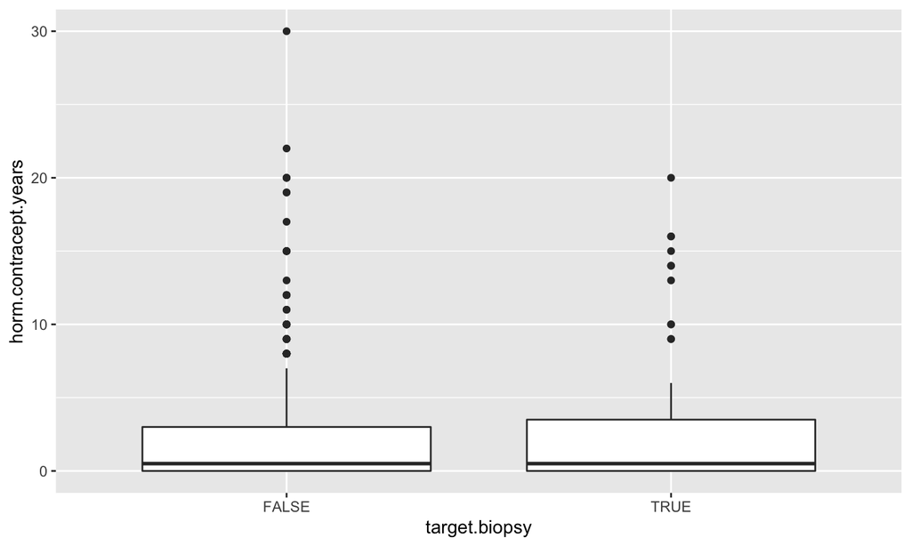

## Inspecting some columns (1)

```r
summary(data$STDs.number)
```

```
##    Min. 1st Qu.  Median    Mean 3rd Qu.    Max.    NA's
##  0.0000  0.0000  0.0000  0.1766  0.0000  4.0000     105
```

- Strange numbers!
- Many outliers

## A bit more detail with `table()`

```r
table(data$STDs.number, useNA="always")
```

```
##
##    0    1    2    3    4 <NA>
##  674   34   37    7    1  105
```

- This explains the strange `summary()` result.
- Why are there so many NAs?

## The smoking data

```
##    smoker         smoke.years    smokes.packs.year
##  Mode :logical   Min.   : 0.00   Min.   : 0.0000
##  FALSE:722       1st Qu.: 0.00   1st Qu.: 0.0000
##  TRUE :123       Median : 0.00   Median : 0.0000
##  NA's :13        Mean   : 1.22   Mean   : 0.4531
##                  3rd Qu.: 0.00   3rd Qu.: 0.0000
##                  Max.   :37.00   Max.   :37.0000
##                  NA's   :13      NA's   :13
```

- Obviously, these three variables describe the exact same thing!
- Let’s investigate this further and deal with it

## Smoker data corrupted?

```r
sum(data$smoker, na.rm=T)
```

```
## [1] 123
```

```r
tmp <- data$smoker & data$smoke.years > 0 & data$smokes.packs.year > 0
sum(tmp, na.rm=T)
```

```
## [1] 123
```

Probably not, but row 4 is dodgy at the least:

```
##   age smoker smoke.years smokes.packs.year
## 4  52   TRUE          37                37
```

I’ll investigate further

```r
data[!is.na(data$smoke.years) & data$smoke.years > 0
     & data$smoke.years == data$smokes.packs.year, c(5,6,7)]
```

```
##     smoker smoke.years smokes.packs.year
## 4     TRUE          37                37
## 62    TRUE          19                19
## 68    TRUE          21                21
## 97    TRUE          15                15
## 175   TRUE          12                12
## 213   TRUE           5                 5
## 290   TRUE           3                 3
## 378   TRUE           3                 3
## 427   TRUE           5                 5
## 468   TRUE           5                 5
## 479   TRUE           9                 9
## 593   TRUE           6                 6
## 632   TRUE           3                 3
## 663   TRUE          22                22
```

What do you think happened here?

## A closer inspection

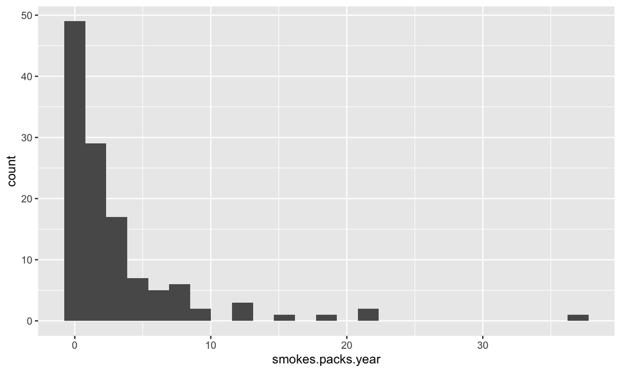

**This cannot be packs per year! Most smokers smoke 1-7 packs per week! (exactly what this histogram shows)**

## Dealing with data corruption

Two options remain for the `smokes.packs.year` column:  
- adjust the units manually as I think is correct  
- discard the column

Since the smoking data is redundant, I will choose the latter

## Variable engineering: “factorization”

Condense the ‘smoking’ data into one variable and start building a ‘clean’ dataset:

```r
smoking <- cut(data$smoke.years,
               breaks = c(0, 1, 5, 12, 100),
               labels = c("no", "short", "medium", "long"),
               ordered_result = T,
               right = F)
clean_data <- cbind(data[, 1:4], smoking, data[, 8:ncol(data)])
table(smoking)
```

```
## smoking
##     no  short medium   long
##    726     42     44     33
```

## Data redundancy in STD variables

There are many variables related to STDs:

```
##  [1] "STD_condylomatosis" "STD_cervical.cond"  "STD_vaginal.cond"
##  [4] "STD_vulvo.per.cond" "STD_syph"           "STD_pid"
##  [7] "STD_gen.herpes"     "STD_moll.cont"      "STD_aids"
## [10] "STD_hiv"            "STD_hepB"           "STD_HPV"
```

Some of them completely redundant, and most with extremely low (useless) counts

```r
table(data$STDs.number)
```

```
##
##   0   1   2   3   4
## 674  34  37   7   1
```

These are the counts of occurrences of individual STDs:

```
## STD_condylomatosis  STD_cervical.cond   STD_vaginal.cond
##                 44                  0                  4
## STD_vulvo.per.cond           STD_syph            STD_pid
##                 43                 18                  1
##     STD_gen.herpes      STD_moll.cont           STD_aids
##                  1                  1                  0
##            STD_hiv           STD_hepB            STD_HPV
##                 18                  1                  2
```

## Recoding variables

## Recoding strategies

Several options

- Factorization: convert to factor
  - seen with Smoking data
- Normalization
  - min-max normalization
  - scaling normalization
- When numeric attributes are required: dummy coding

## min-max normalization

- pro: easy, transparent
- used for normalization from 0 to 1
- danger: unseen data with wider distribution
  - define theoretical extremes

This is how to do it in R

```r
scale_min_max <- function(x) (x - min(x)) / (max(x) - min(x))
```

## min-max demo

```r
x <- c(2, -1, 3, 5, 0, 4)
round(scale_min_max(x), 2)
```

```
## [1] 0.50 0.00 0.67 1.00 0.17 0.83
```

## scaling normalization

\[x' = \frac{x-\bar{x}}{\sigma}\] - Built into R:

```r
x <- c(2, -1, 3, 5, 0, 4)
round(scale(x), 2)[,1]
```

```
## [1] -0.07 -1.37  0.36  1.22 -0.94  0.79
```

## dummy encoding

how to change this factor in a numeric representation usable for clustering etc?

```
## [1] dog cat cat dog rat
## Levels: cat dog rat
```

## dummy coding pets

The essence is binary splitting:

- dog/not dog
- cat/not cat
- rat/not rat

## dummy coding in R

```r
dummies::dummy.data.frame(data.frame(favour=pet_favour), sep="_")
```

```
##   favour_cat favour_dog favour_rat
## 1          0          1          0
## 2          1          0          0
## 3          1          0          0
## 4          0          1          0
## 5          0          0          1
```

## The dependent variable

Oh no, there are four!

```
## [1] "target.hinselman" "target.schiller"  "target.cytology"
## [4] "target.biopsy"
```

**Which are you going to use?**

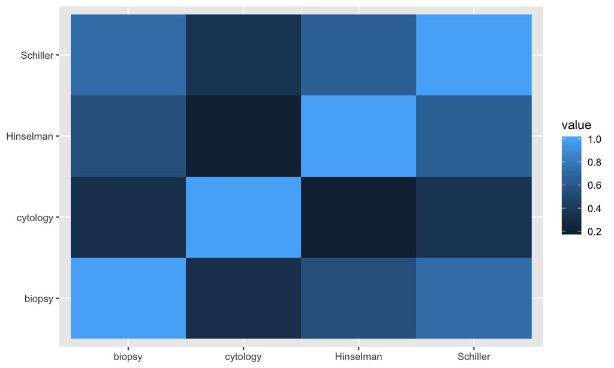

This shows the correlation between the four target variables.

## Exploring covariance

## Exploring covariance

Typically, relationships between variables are visualized using scatterplots, but other strategies exist. Several are explored here.

## The standard scatterplot

A simple scatterplot looking at the relationship between `first.sex` and `num.partners`.

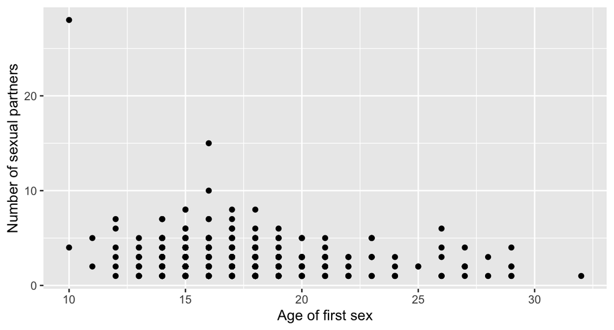

## Improve with alpha parameter to `geom_point`

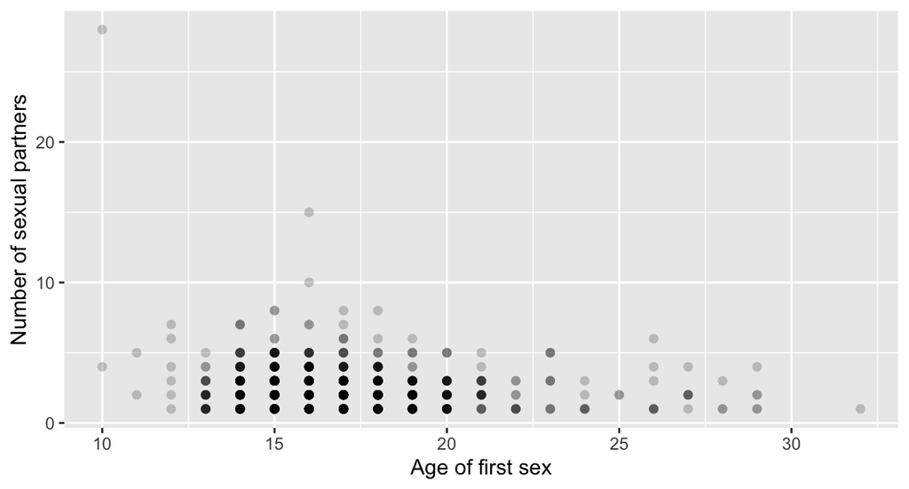

## Improve with `geom_jitter`

(and combine with `alpha` parameter)

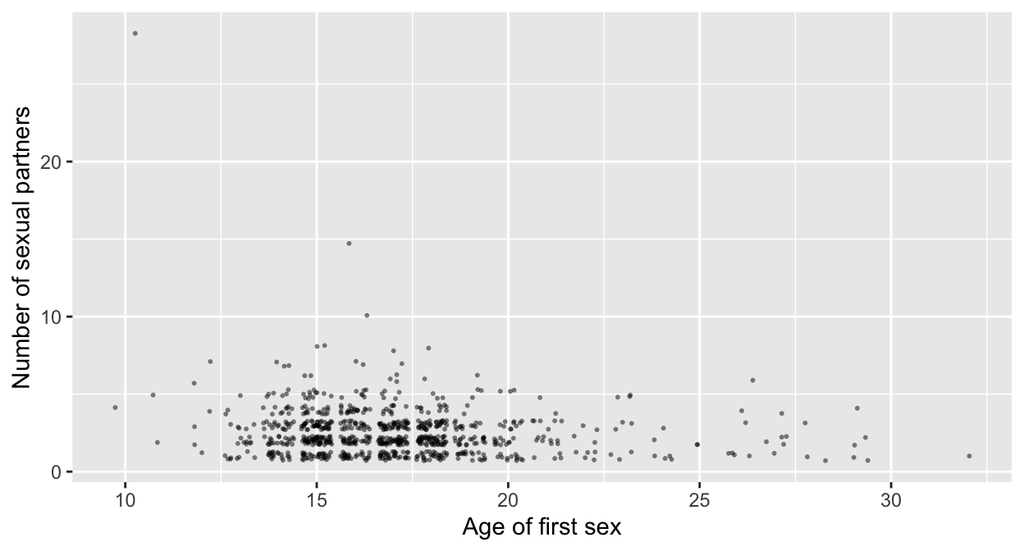

## Improve by omitting outliers

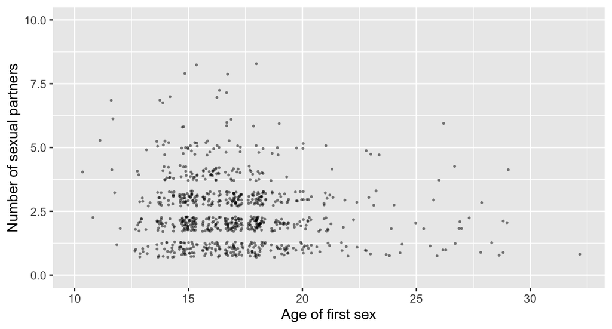

## Improve by adding trend line

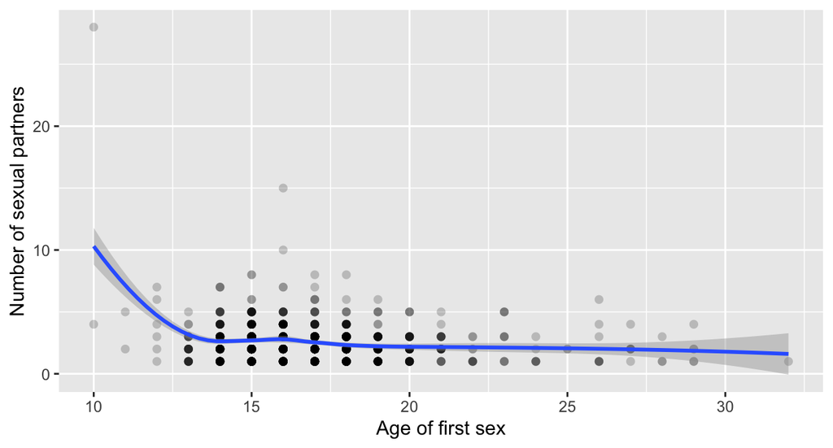

- Shows the high impact of a single outlier!
- In contrast with common belief, no apparent relationship is visible

## Improve by binning

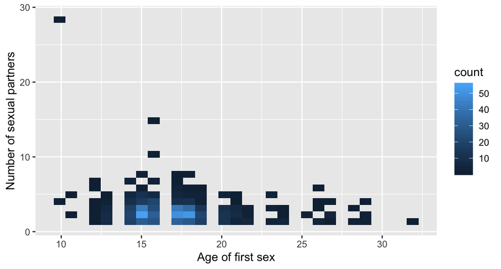

## Look for patterns with the dependent variable

## Why?

- The dependent variable is the thing you are interested in!
- It is a good idea to investigate variables in relation with the dependent variable

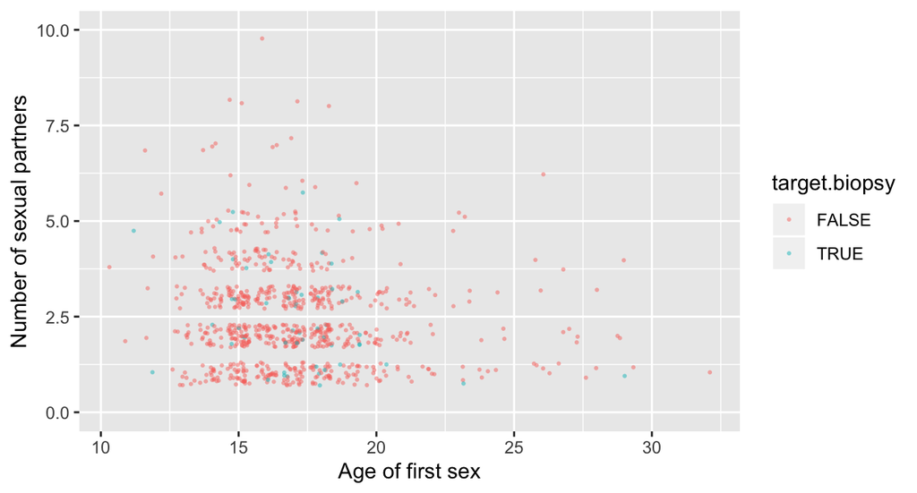

## Density plots show class distinction

A density plot will often quickly reveal whether there is promise in a variable. I’ll demonstrate with the `iris` dataset.

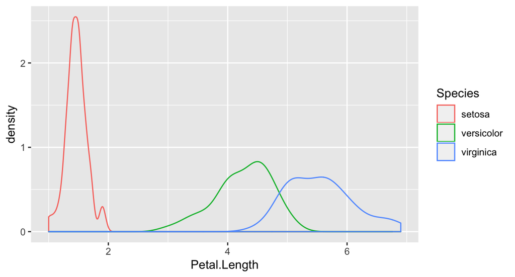

In this plot, you can see that Setosa separates quite nicely, by the other two don’t.

## The ‘xor’ problem

The density approach is not flawless! Consider this:

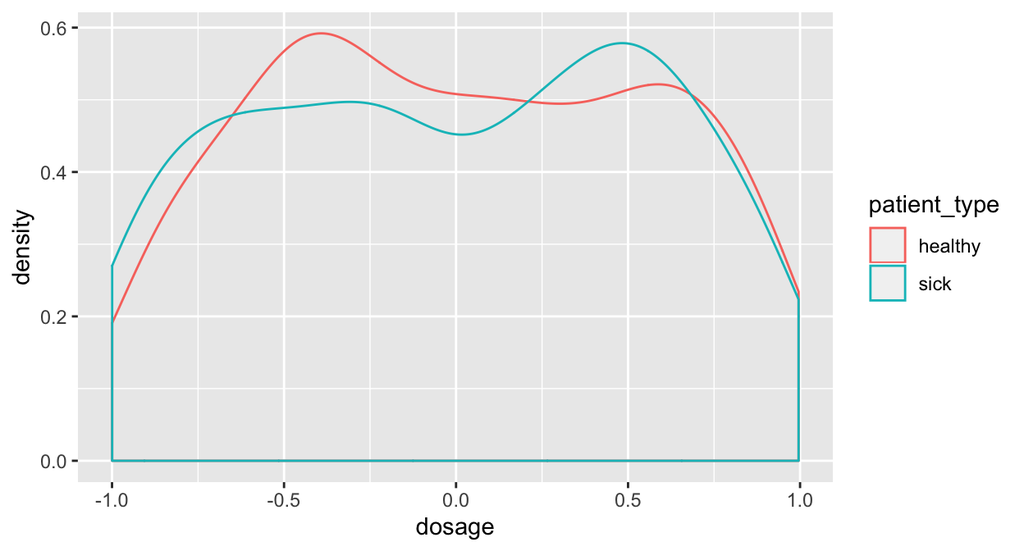

This looks like there is little to win, doesn’t it?  
Here’s another view of the same data!

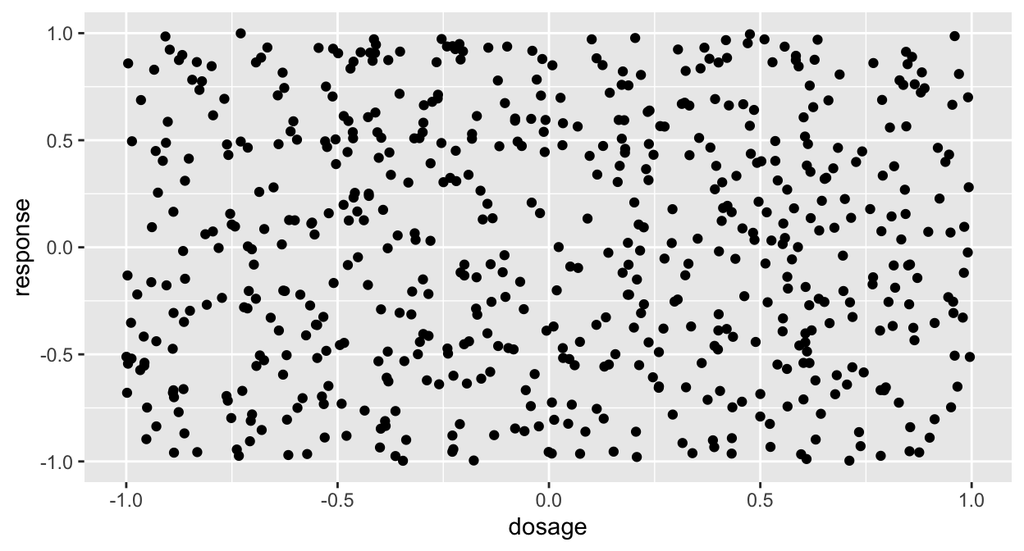

Still not interesting!  
Give it one more shot:

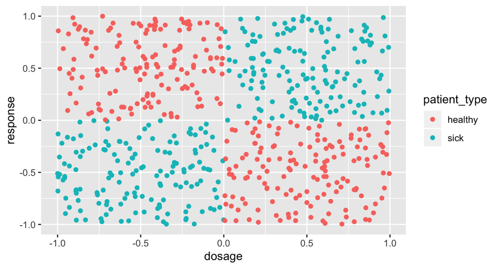

## Advanced Explorations

## PCA

Here are the irises again.

```r
ir.pca <- prcomp(iris[, -5],
                 center = TRUE,
                 scale. = TRUE)
print(ir.pca)
```

```
## Standard deviations (1, .., p=4):
## [1] 1.7083611 0.9560494 0.3830886 0.1439265
##
## Rotation (n x k) = (4 x 4):
##                     PC1         PC2        PC3        PC4
## Sepal.Length  0.5210659 -0.37741762  0.7195664  0.2612863
## Sepal.Width  -0.2693474 -0.92329566 -0.2443818 -0.1235096
## Petal.Length  0.5804131 -0.02449161 -0.1421264 -0.8014492
## Petal.Width   0.5648565 -0.06694199 -0.6342727  0.5235971
```

## Plot variances

The plot method returns a plot of the variances (y-axis) associated with the PCs (x-axis).

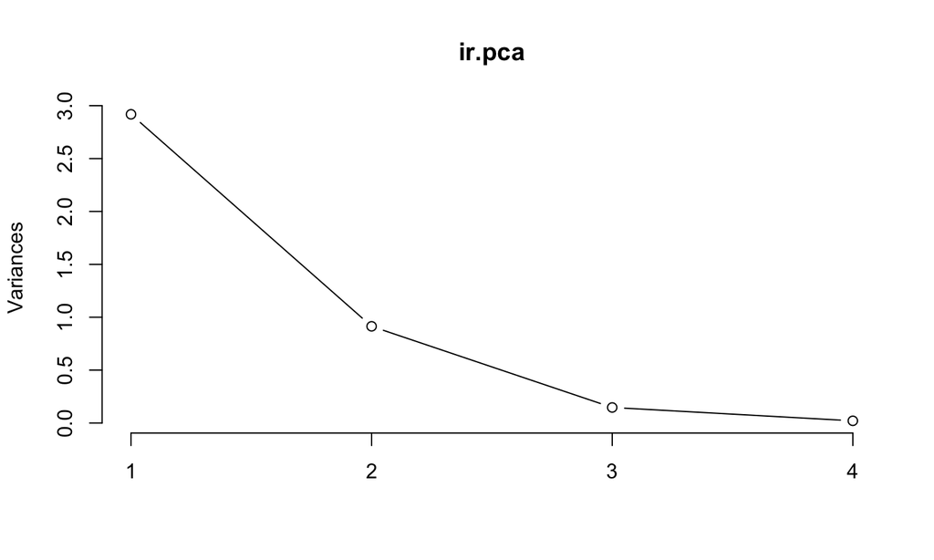

```r
plot(ir.pca, type = "l")
```

## Summary

The summary method describe the importance of the PCs.

```r
summary(ir.pca)
```

```
## Importance of components:
##                           PC1    PC2     PC3     PC4
## Standard deviation     1.7084 0.9560 0.38309 0.14393
## Proportion of Variance 0.7296 0.2285 0.03669 0.00518
## Cumulative Proportion  0.7296 0.9581 0.99482 1.00000
```

## The PC plot

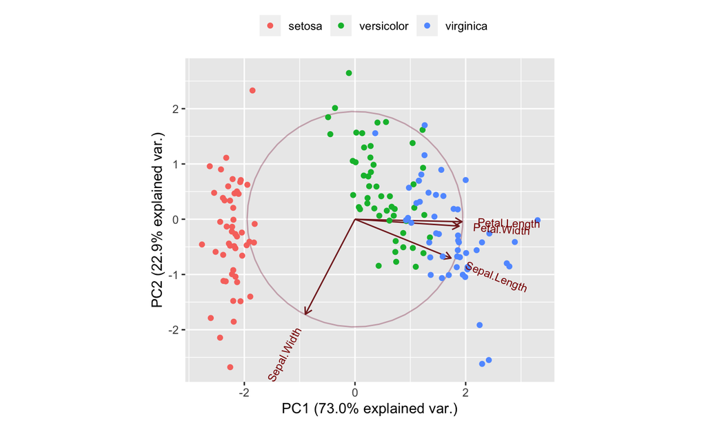

## Clustering

- Using clustering, you can sometimes see obvious patterns in the data.
- Most obvious are:
  - k-Means clustering
  - Hierarchical clsutering

## k-Means clustering

k-means is very sensitive to the scale of your data so you’ll need to normalize it.